## HEADER

Who:KK

What: Statistics for Data science

Last edited: 2023-04-04

## CONTENTS

correlation

ANOVA

t-test

Mann-Whitney U-test

Linear regression

## correlation

correlation is defined as the whether there is demnostratable a association between two continous numeric variables. correlation measured from -1 to +1. the correlation quantified as either being +1 which means positive correlation and -1 which means negative correlation and 0 which means no correlation.

# Testing Assumptions

Before performing we should keep in mind that Null hypothesis and alternate hypothesis.And alph p_value which is 0.05(significance level).If p-value is more than 0.05 we accept our Null hypothesis whic means no relationship.If p-value is less than 0.05 we reject null hypothesis and accept Alternate hypothesis which means there is association between them.

# load the data

```r
library(car)
data("iris") #inbuild data in R
print(iris)
```

```
##     Sepal.Length Sepal.Width Petal.Length Petal.Width    Species
## 1            5.1         3.5          1.4         0.2     setosa
## 2            4.9         3.0          1.4         0.2     setosa
## 3            4.7         3.2          1.3         0.2     setosa
## 4            4.6         3.1          1.5         0.2     setosa
## 5            5.0         3.6          1.4         0.2     setosa
## 6            5.4         3.9          1.7         0.4     setosa
## 7            4.6         3.4          1.4         0.3     setosa
## 8            5.0         3.4          1.5         0.2     setosa
## 9            4.4         2.9          1.4         0.2     setosa
## 10           4.9         3.1          1.5         0.1     setosa
## 11           5.4         3.7          1.5         0.2     setosa
## 12           4.8         3.4          1.6         0.2     setosa
## 13           4.8         3.0          1.4         0.1     setosa
## 14           4.3         3.0          1.1         0.1     setosa
```

[output cut: 136 more lines]

```r
View(iris)
```

# About the dataset

This dataset is about measurements in centimeters of the variables such as sepal length and width and petal length and width, respectively, for 50 flowers from each of 3 species of iris.the species are iris setosa,verscicolor, and virginica.

The order of operation for correlation is 1.Question 2.Graph 3.Test 4.validate(eg. test our assumption)

# 1.Question(the data must be continous numeric variable)

we are going to find whether their is correlation between sepal length and width.

# 2. Graph(graph the data for visualization)

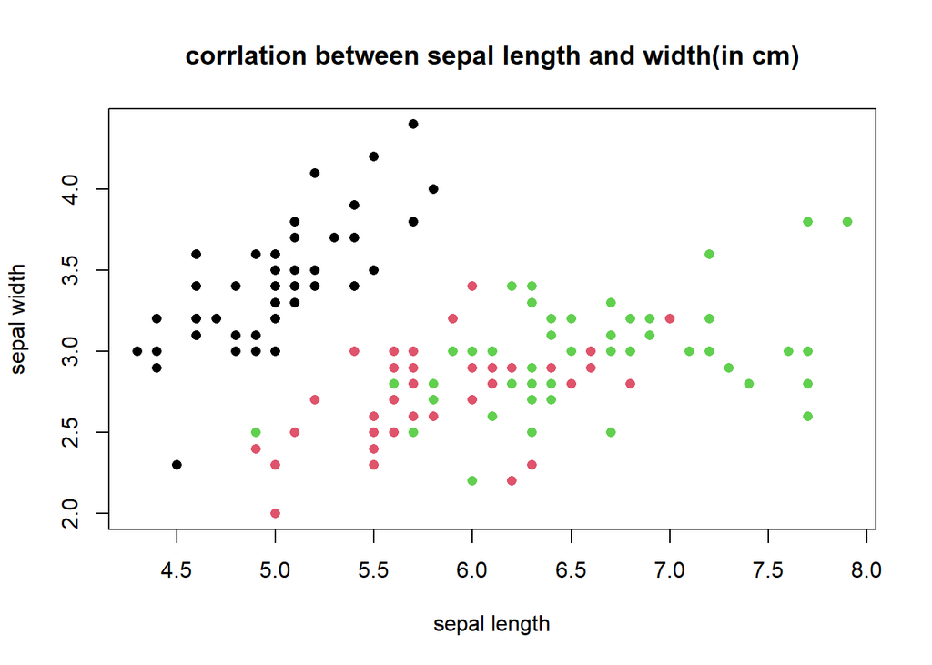

```r
plot(iris$Sepal.Length, iris$Sepal.Width,
     xlab = "sepal length",
     ylab = "sepal width",
     main = "corrlation between sepal length and width(in cm)",
     col = iris$Species, pch = 16)
```

# 3.Test

```r
cor.test(iris$Sepal.Length, iris$Sepal.Width)
```

```
##
##  Pearson's product-moment correlation
##
## data:  iris$Sepal.Length and iris$Sepal.Width
## t = -1.4403, df = 148, p-value = 0.1519
## alternative hypothesis: true correlation is not equal to 0
## 95 percent confidence interval:
##  -0.27269325  0.04351158
## sample estimates:
##        cor
## -0.1175698
```

From the output we can say that the p- value is 0.15 which high compared to our (alpha value 0.05) so we can accept our Null hypothesis which means there is nocorrelation between sepal length and width.

# 4.Validate(checking the assumption of our data is normally distributed or not)

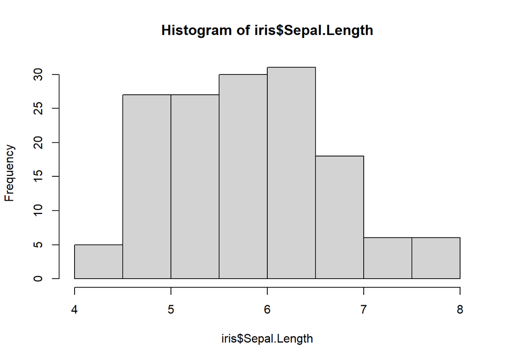

```r
hist(iris$Sepal.Length)
```

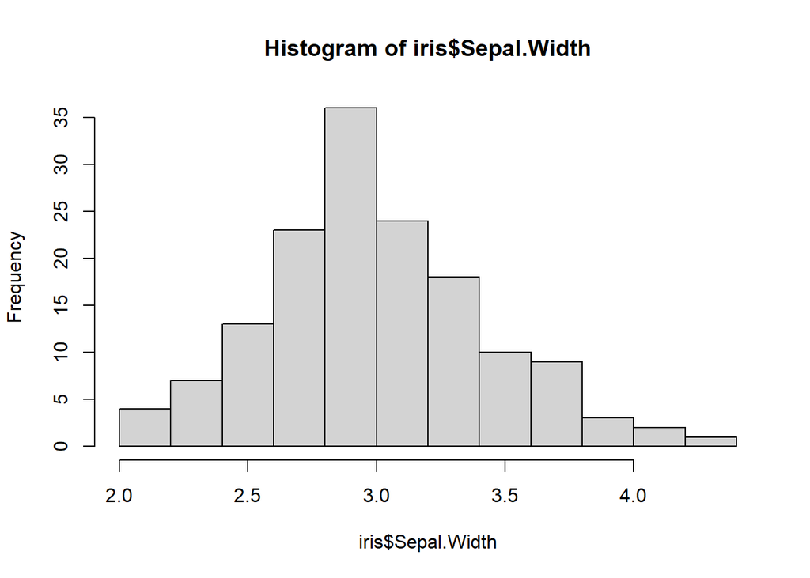

```r
hist(iris$Sepal.Width)
```

# Results

By performing correlation between sepal length and width we can say that there is no significant association between sepal length and width of the all three species.Here p-value is very important which is more than our significance level(0.05) which means we should accept our null hypothesis.And our corrleation value is -0.117 which suggest that their is weak negative correlation. from the hypothesis testing we can say that there is not enough evidence to suggest a correlation between sepal length and width.

## ANOVA

Analysis of variance is used to compare multiple sample with a single test.it is used when the categorical features has more than two categories.Anova are two types one way Anova it is performed when their is a only one independent variable and two way anova performed wwhen there is more than one independent variable.

# Features to be considered

Null hypothesis - if all pairs of sample means are equal. Altrenate hypothesis - if one pair of sample mean is different.

```r
pest <- structure(list(damage = c(113.7, 94.4, 103.6,
                                  106.3, 104, 98.9,
                                  115.1, 99.1, 120.2, 99.4,
                                  88, 97.9, 61.1, 72.2, 73.7,
                                  81.4, 72.2, 48.4, 50.6, 88.2,
                                  46.9, 32.2, 48.3, 62.1, 69,
                                  45.7, 47.4, 32.4, 54.6, 43.6,
                                  104.6, 107, 110.4, 93.9, 105,
                                  82.8, 92.2, 91.5, 75.9, 100.4),
                       treatment = c("control", "control",
                                     "control", "control",
                                     "control", "control",
                                     "control", "control",
                                     "control", "control",
                                     "x.half", "x.half",
                                     "x.half", "x.half",
                                     "x.half", "x.half",
                                     "x.half", "x.half",
                                     "x.half", "x.half",
                                     "x.full", "x.full",
                                     "x.full", "x.full",
                                     "x.full", "x.full",
                                     "x.full", "x.full",
                                     "x.full", "x.full",
                                     "organic", "organic",
                                     "organic", "organic",
                                     "organic", "organic",
                                     "organic", "organic",
                                     "organic", "organic")),
                  class = "data.frame",
                  row.names = c(NA, -40L))
pest$treatment <- factor(pest$treatment) #convert character to factor
```

# About the dataset

Think of this data as the result of an experiment looking at the effectiveness of pesticide treatment on leaf damage. Let us imagine that this experiment measured leaf damage (variable “damage” measured in mm squared) and that the plants were treated with one of 4 treatment levels: Variable treatment with levels 1.control 2.x.half 3.x.full 4.organic

The experiment is of course designed to look at an overall effect the various treatments may have to reduce leaf damage relative to the control. In addition, it is of interest to examine the effect of the organic treatment compared to that of the x.half to the x.full.The experiment ran using 40 potted plants spaced 1m from each other in a greenhouse setting. Each treatment was randomly assigned to 10 plants. Onto each plant was placed 5 red lily beetle (Lilioceris lilii) pairs.

# Explore the data

```r
head(pest)
```

```
##   damage treatment
## 1  113.7   control
## 2   94.4   control
## 3  103.6   control
## 4  106.3   control
## 5  104.0   control
## 6   98.9   control
```

```r
summary(pest)
```

```
##      damage         treatment
##  Min.   : 32.20   control:10
##  1st Qu.: 59.48   organic:10
##  Median : 88.10   x.full :10
##  Mean   : 80.86   x.half :10
##  3rd Qu.:101.20
##  Max.   :120.20
```

```r
levels(pest$treatment)
```

```
## [1] "control" "organic" "x.full"  "x.half"
```

# extract variables

```r
damage = pest$damage
treatment = pest$treatment
```

#compare mean of data

```r
tapply(damage, treatment, mean) #mean of all groups
```

```
## control organic  x.full  x.half
##  105.47   96.37   48.22   73.37
```

```r
tapply(damage, treatment, length) #sample of all groups
```

```
## control organic  x.full  x.half
##      10      10      10      10
```

# plot the data using boxplot()

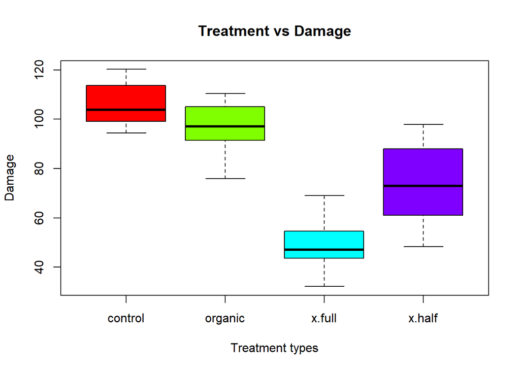

```r
boxplot(damage ~ treatment,
        xlab = 'Treatment types',
        ylab = 'Damage',
        main = 'Treatment vs Damage',
        col = rainbow(4))
```

# perform anova test aov()

```r
result <- aov(damage ~ treatment, data = pest)
summary(result)
```

```
##             Df Sum Sq Mean Sq F value   Pr(>F)
## treatment    3  19677    6559   44.19 3.73e-12 ***
## Residuals   36   5343     148
## ---
## Signif. codes:  0 '***' 0.001 '**' 0.01 '*' 0.05 '.' 0.1 ' ' 1
```

# Examine the assumption of gaussian

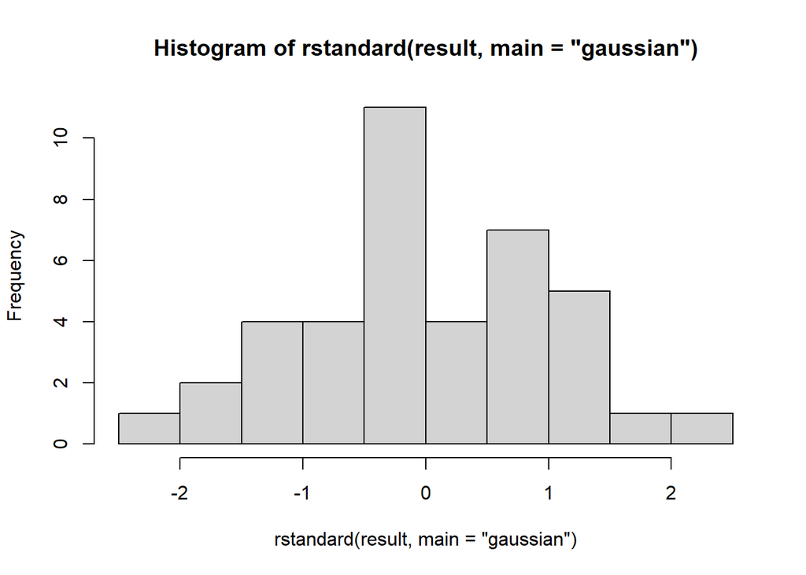

```r
hist(rstandard(result, main = "gaussian"))
```

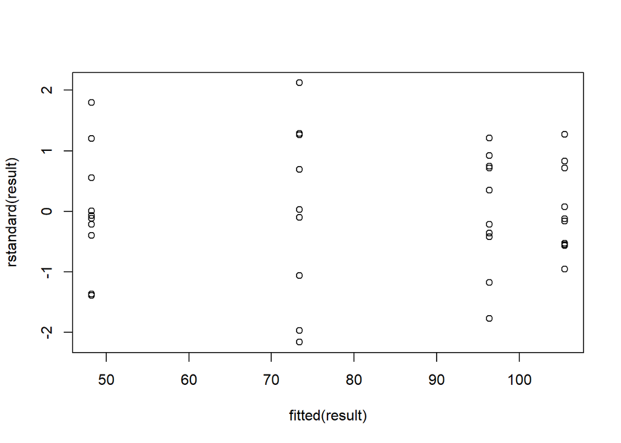

```r
plot(rstandard(result) ~ fitted(result))
```

# Barlett test (Homogenity of variance performed on the variable damage with each level of treatment)

```r
bartlett.test(damage ~ treatment)
```

```
##
##  Bartlett test of homogeneity of variances
##
## data:  damage by treatment
## Bartlett's K-squared = 3.916, df = 3, p-value = 0.2707
```

p-value is more than alpha value which means we can accept null hypothesis.so which means some group of treatment shares the same level of variance.

# posthoc test

```r
TukeyHSD(result)
```

```
##   Tukey multiple comparisons of means
##     95% family-wise confidence level
##
## Fit: aov(formula = damage ~ treatment, data = pest)
##
## $treatment
##                   diff       lwr       upr     p adj
## organic-control  -9.10 -23.77379   5.57379 0.3538657
## x.full-control  -57.25 -71.92379 -42.57621 0.0000000
## x.half-control  -32.10 -46.77379 -17.42621 0.0000056
## x.full-organic  -48.15 -62.82379 -33.47621 0.0000000
## x.half-organic  -23.00 -37.67379  -8.32621 0.0008695
## x.half-x.full    25.15  10.47621  39.82379 0.0002718
```

# post hoc test is performed to compare mean of each group effect.

organic and control has no difference. for x.full vs control and organic has lot of difference. for x.half vs control and organic has a difference. even x.half and x.full have some difference.

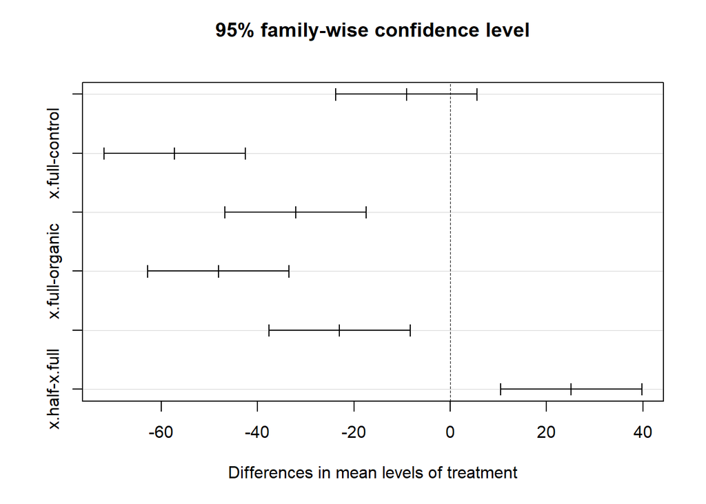

```r
plot(TukeyHSD(result))
```

# Result

## T-test

T-test is used to compare means of between two groups.

# T-test for 2 independent samples

```r
density <- c("high","high","high","high","high","high","high",
             "low","low","low","low","low","low","low")
height <- c(2.1,3.5,4.3,3.2,4.5,3.7,2.7,
            6.1,8,6.9,9.1,7.5,8,7.4)
(treegrowth <- data.frame(density,height))
```

```
##    density height
## 1     high    2.1
## 2     high    3.5
## 3     high    4.3
## 4     high    3.2
## 5     high    4.5
## 6     high    3.7
## 7     high    2.7
## 8      low    6.1
## 9      low    8.0
## 10     low    6.9
## 11     low    9.1
## 12     low    7.5
## 13     low    8.0
## 14     low    7.4
```

# About the dataset

The example we will use here is the amount of tree growth over a period of time,where samples were taken of individual trees grown under two conditions - high density of trees versus low density.The hypothesis we are testing is whether there is evidence the samples came from different populations.by inference, we are possibly interested in whether there is an effect of density on growth.

#make a graph with hist(check for the gaussian)

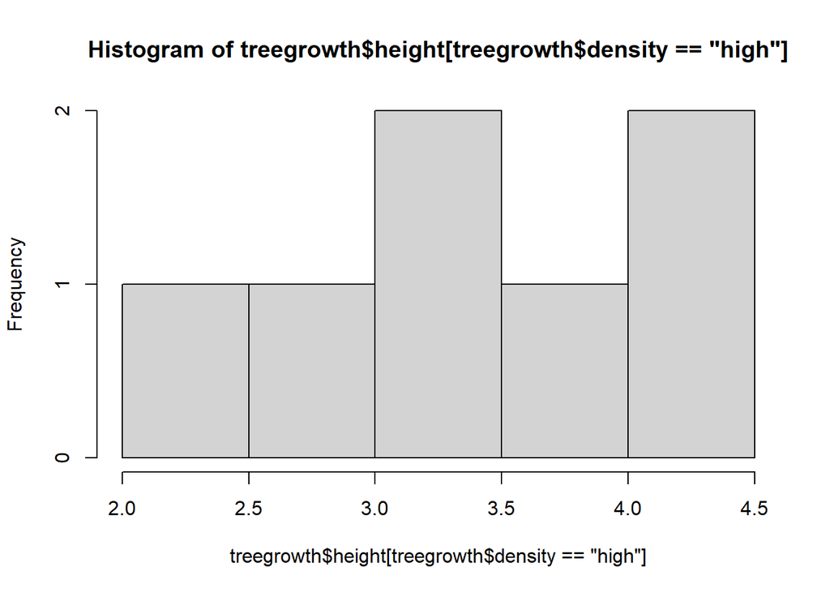

```r
hist(treegrowth$height[treegrowth$density=="high"])
```

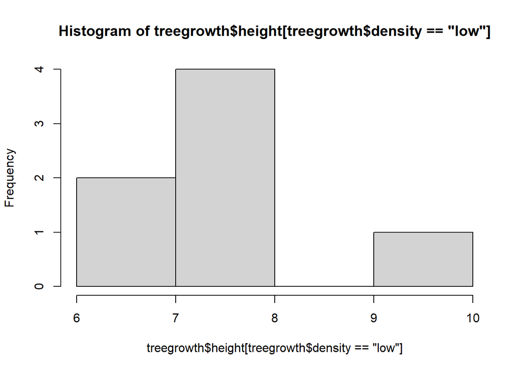

```r
hist(treegrowth$height[treegrowth$density=="low"])
```

#make qqplot(check the normality of data)

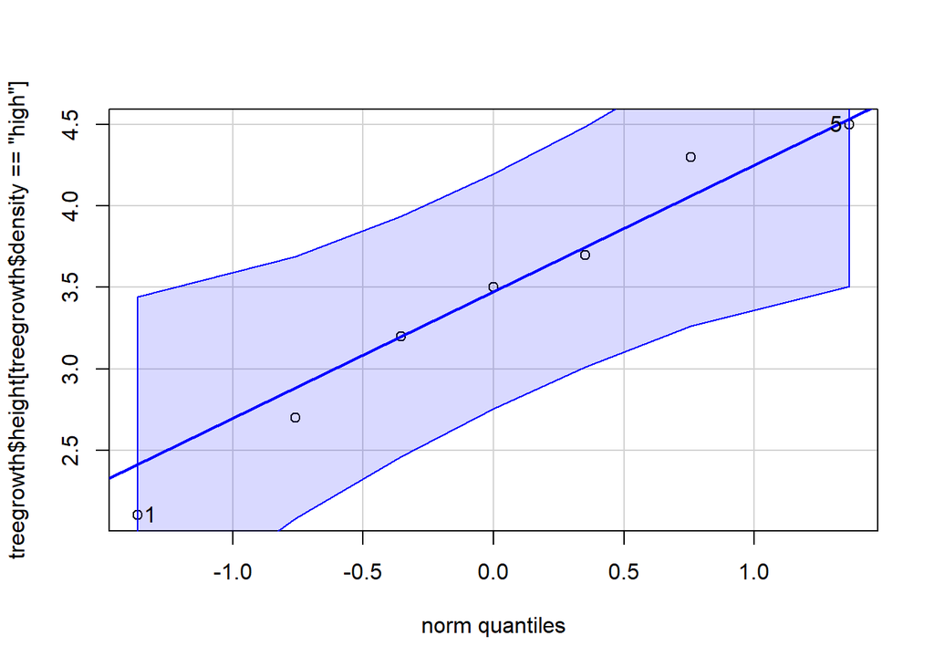

```
## [1] 1 5
```

```r
library(car)
qqPlot(treegrowth$height[treegrowth$density=="high"])
```

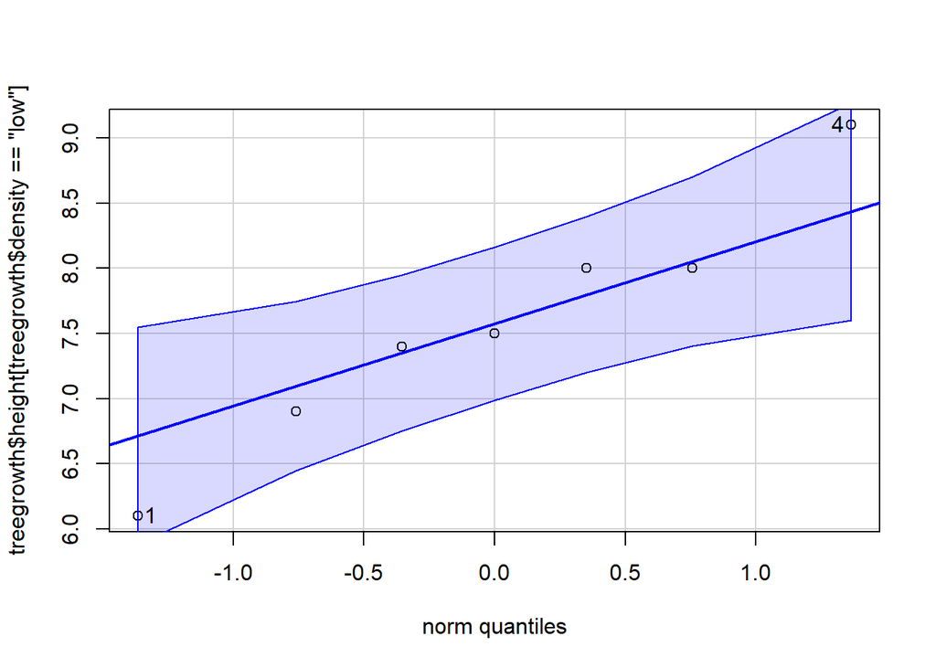

```
## [1] 4 1
```

```r
qqPlot(treegrowth$height[treegrowth$density=="low"])
```

#perform t-test

```r
t.test(formula = height ~ density, data = treegrowth)
```

```
##
##  Welch Two Sample t-test
##
## data:  height by density
## t = -8.6257, df = 11.868, p-value = 1.865e-06
## alternative hypothesis: true difference in means between group high and group low is not equal to 0
## 95 percent confidence interval:
##  -5.190611 -3.095103
## sample estimates:
## mean in group high  mean in group low
##           3.428571           7.571429
```

# make a graph with boxplot

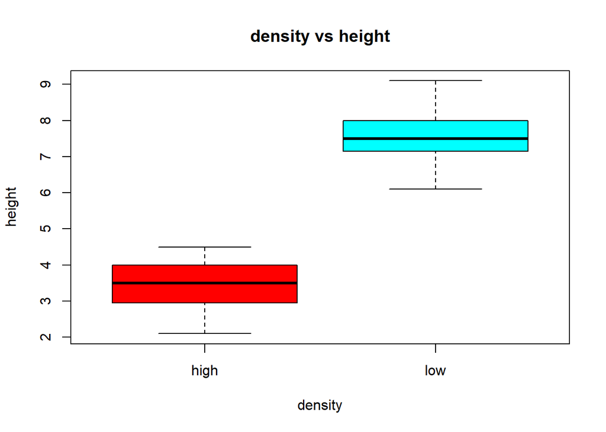

```r
boxplot(height ~ density,
        xlab = "density",
        ylab = "height",
        main = "density vs height",
        col = rainbow(2))
```

#Result

By performing t-test we can say that both sample came from different population,there is evidence that p-value is less than alpha value which means we reject null hypothesis and accept alternate hypothesis.and also mean of high density is3.42 while for low density is 7.57.

# one sample t-test

```r
earwigs <- c(22.1, 16.3, 19.1, 19.9, 19.2, 17.7, 22.5, 17.7, 24.1, 17.8,
             21.9, 24.9, 13.8, 17.2, 17.6, 19.9, 17.1, 10, 10.7, 22)
mymu <- 17.0
```

# About the dataset

The example is a sample of earwigs measured in length to the nearest 0.1 mm.There is a hypothesis that global warming has impacted the development in the population and they are getting larger. A long term dataset has established a mean earwig length of 17.0 (NB, this is our estimate of “mu”, the population mean we will compare our sample to). Are the earwigs getting bigger?

# check for normality

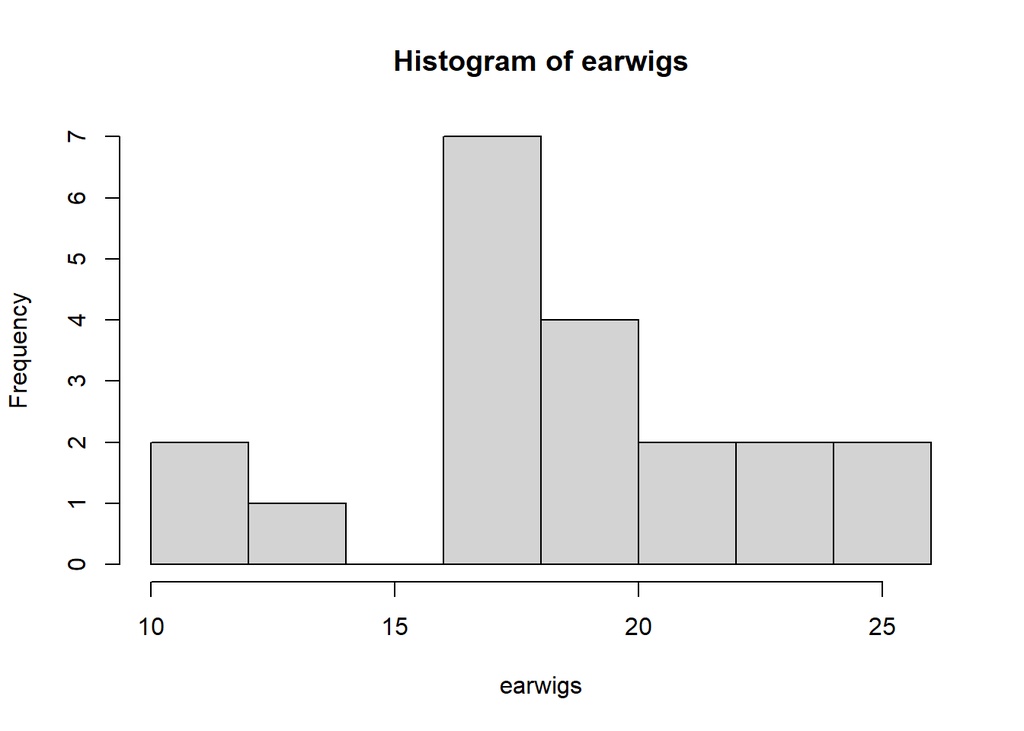

```r
hist(earwigs)
```

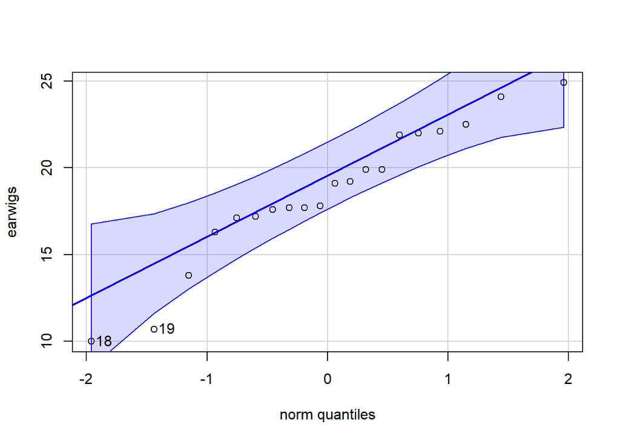

```
## [1] 18 19
```

```r
qqPlot(earwigs)
```

#perform t-test

```r
t.test(x = earwigs,
       mu = mymu)
```

```
##
##  One Sample t-test
##
## data:  earwigs
## t = 1.7845, df = 19, p-value = 0.09031
## alternative hypothesis: true mean is not equal to 17
## 95 percent confidence interval:
##  16.72775 20.42225
## sample estimates:
## mean of x
##    18.575
```

# Result

we found no evidence that mean length of earwigs in our sample was different to the historical mean.

# Two paired sample test

```r
cort.t0 <- c(0.59, 0.68, 0.74, 0.86, 0.54, 0.85, 0.7, 0.81, 0.79, 0.76,
             0.49, 0.64, 0.74, 0.51, 0.57, 0.74, 0.77, 0.72, 0.52, 0.49)

cort.t1 <- c(1.13, 0.81, 0.77, 0.72, 0.45, 0.9, 0.7, 0.7, 0.98, 0.96, 1.1,
             0.63, 0.91, 1.1, 0.99, 0.72, 1.11, 1.2, 0.77, 0.91)
```

# About the dataset

The example here is a measure of the hormone cortisol in pregnant cows (related to stress in mammals). A measure was taken in each individual twice; once as a baseline measure, and once after a treatment of soothing music being played to the cows for 3 hours per day. The prediction is that the mean level of cortisol will decrease relative to baseline after experiencing the music treatment.

# Check for normality

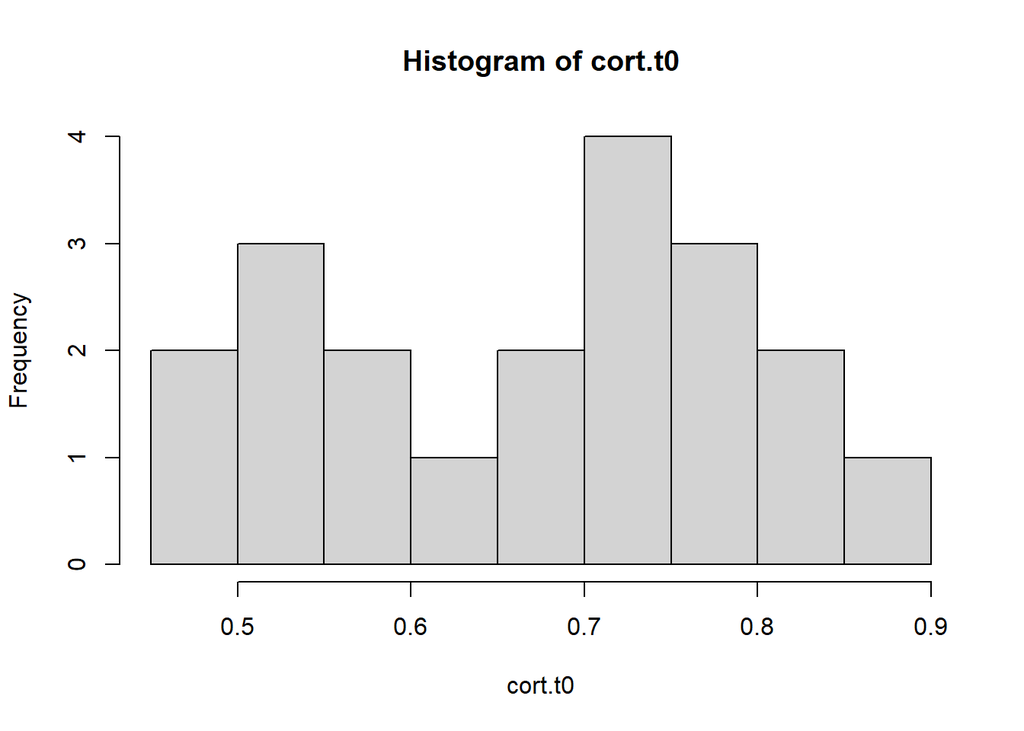

```r
hist(cort.t0)
```

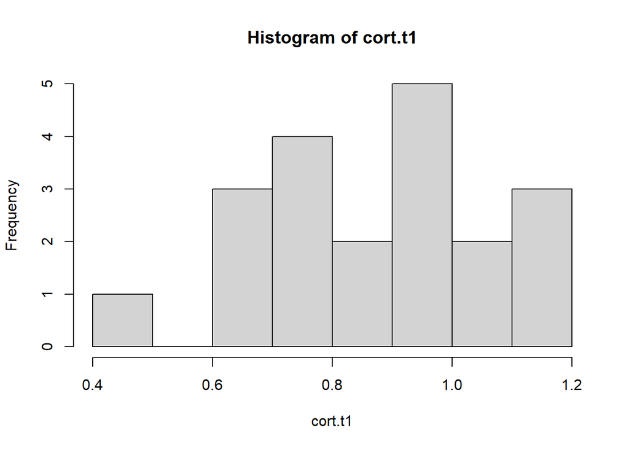

```r
hist(cort.t1)
```

#Check for qqplot

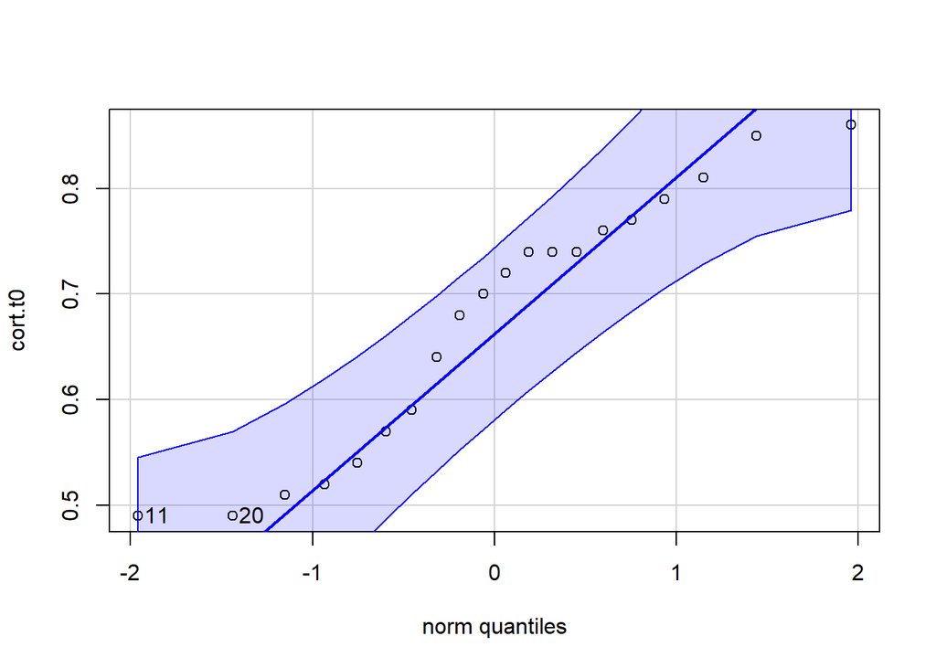

```
## [1] 11 20
```

```r
qqPlot(cort.t0)
```

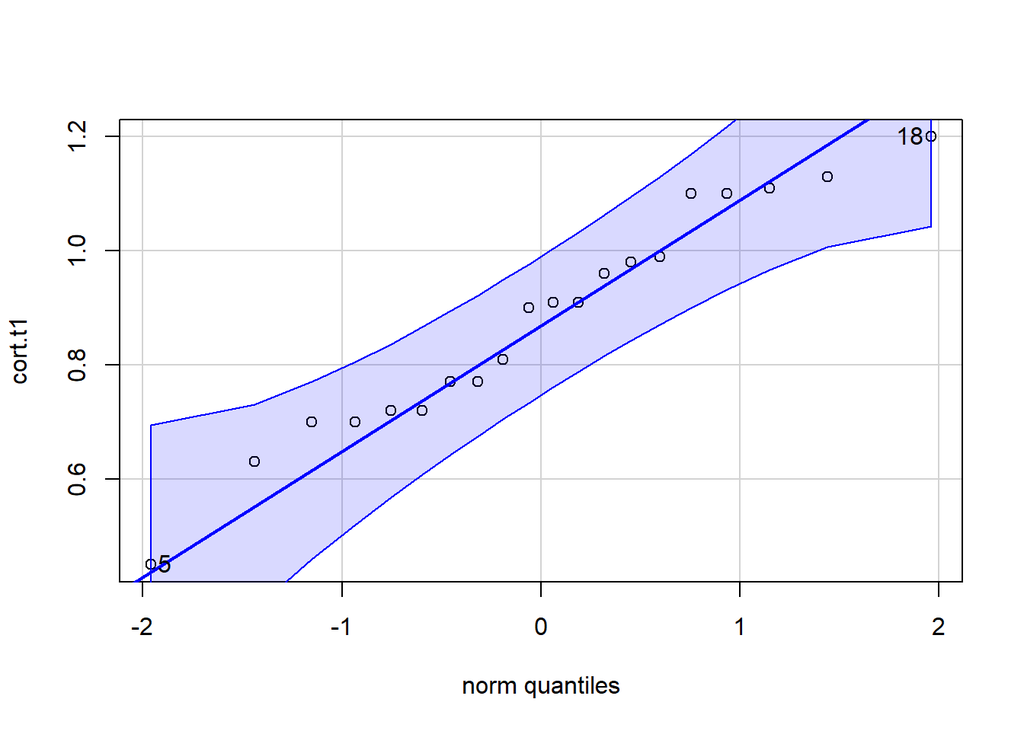

```
## [1]  5 18
```

```r
qqPlot(cort.t1)
```

# perform t-test

```r
t.test(cort.t0, cort.t1, paired = TRUE)
```

```
##
##  Paired t-test
##
## data:  cort.t0 and cort.t1
## t = -3.7324, df = 19, p-value = 0.001412
## alternative hypothesis: true mean difference is not equal to 0
## 95 percent confidence interval:
##  -0.31605728 -0.08894272
## sample estimates:
## mean difference
##         -0.2025
```